# Clustering

Análisis de segmentación y caracterización de clústeres

Author

Dante Conti, Sergi Ramirez, (c) IDEAI

Published

March 16, 2026

Modified

March 16, 2026

En este documento se presentan los principales enfoques de clustering aplicados sobre una base de datos de comportamiento de compra.

La idea no es únicamente ejecutar funciones, sino entender qué hace cada técnica, cuándo conviene usarla y cómo interpretar los resultados. A lo largo del material se combinan ejemplos ejecutables con fragmentos ilustrativos que sirven como plantilla para otros conjuntos de datos.

**Mostrar código**

```r
# Cargamos las librerías necesarias.
# Se incluyen paquetes para:
# - manipulación y visualización
# - clustering particional y jerárquico
# - métricas de validación
# - representación gráfica de dendrogramas
list.of.packages <- c(
  "dplyr", "fpc", "reshape2", "tidyr", "ggplot2", "stats",
  "cluster", "factoextra", "colorspace", "patchwork",
  "tidyverse", "ggpubr", "NbClust", "HDclassif", "clustMixType",
  "clusterSim", "pracma", "DataVisualizations", "entropy",
  "clevr", "dendextend", "ggdendro", "gridExtra"
)

new.packages <- list.of.packages[!(list.of.packages %in% installed.packages()[, "Package"])]
if (length(new.packages) > 0) {
  install.packages(new.packages)
}

invisible(lapply(list.of.packages, require, character.only = TRUE))
rm(list.of.packages, new.packages)
```

**Mostrar código**

```r
# Cargamos la base de datos directamente desde GitHub
url <- "https://raw.githubusercontent.com/ramIA-lab/MLforEducation/refs/heads/main/material/clustering/shopping_behavior_updated.csv"
dades <- read.csv(url)
rm(url)
```

**Mostrar código**

```r
# Identificamos el tipo de las variables para separar correctamente
# las cuantitativas de las categóricas.
tipo <- sapply(dades, class)

varNum <- names(tipo)[which(tipo %in% c("integer", "numeric"))]
varNum <- varNum[which(!varNum %in% c("Customer.ID"))]

varCat <- names(tipo)[which(tipo %in% c("character", "factor"))]

# Creamos una copia de trabajo
data <- dades
```

Antes de aplicar cualquier algoritmo, es importante distinguir la naturaleza de las variables. Algunos métodos requieren exclusivamente datos numéricos, mientras que otros permiten trabajar con información mixta. Esta separación será clave más adelante al elegir la distancia y el algoritmo de agrupación.

**Idea clave**

En clustering no existe un método universalmente mejor. La elección depende del tipo de variables, de la distancia utilizada y del objetivo analítico: segmentar, explorar estructura o describir perfiles.

# 1 Métodos Particionales

Los métodos particionales generan una partición directa del conjunto de datos en un número prefijado de grupos. A diferencia de los métodos jerárquicos, aquí se fija el valor de (k) y el algoritmo reasigna observaciones hasta optimizar un criterio interno como la inercia o la disimilitud total.

**Mostrar código**

```r
# Escalamos las variables numéricas para que todas contribuyan de forma comparable.
# Este paso es especialmente importante en métodos basados en distancias.
data <- scale(data[, varNum], center = TRUE, scale = TRUE)
str(data)
```

```
 num [1:3900, 1:4] 0.7188 -1.6484 0.39 -1.5169 0.0613 ...
 - attr(*, "dimnames")=List of 2
  ..$ : NULL
  ..$ : chr [1:4] "Age" "Purchase.Amount..USD." "Review.Rating" "Previous.Purchases"
 - attr(*, "scaled:center")= Named num [1:4] 44.07 59.76 3.75 25.35
  ..- attr(*, "names")= chr [1:4] "Age" "Purchase.Amount..USD." "Review.Rating" "Previous.Purchases"
 - attr(*, "scaled:scale")= Named num [1:4] 15.208 23.685 0.716 14.447
  ..- attr(*, "names")= chr [1:4] "Age" "Purchase.Amount..USD." "Review.Rating" "Previous.Purchases"
```

## 1.1 Calculamos las distintas distancias

Antes de agrupar, conviene estudiar cómo se mide la proximidad entre individuos. La distancia elegida condiciona directamente la forma de los clusters que se obtendrán.

### 1.1.1 Distancia euclídea

Es la distancia geométrica habitual entre dos puntos en un espacio multidimensional. Es una opción natural cuando trabajamos con variables numéricas previamente escaladas.

**Mostrar código**

```r
mat_dist <- dist(x = data, method = "euclidean")
round(as.matrix(mat_dist)[1:5, 1:5], 2)
```

```
     1    2    3    4    5
1 0.00 2.55 1.10 3.69 1.47
2 2.55 0.00 2.53 3.48 2.77
3 1.10 2.53 0.00 2.78 1.32
4 3.69 3.48 2.78 0.00 2.88
5 1.47 2.77 1.32 2.88 0.00
```

### 1.1.2 Distancia basada en la correlación de pearson

Esta medida resulta útil cuando interesa comparar perfiles o patrones de comportamiento más que magnitudes absolutas. Dos individuos pueden quedar próximos si evolucionan de forma similar en las variables, aunque sus valores concretos no coincidan.

**Mostrar código**

```r
mat_dist <- get_dist(x = data, method = "pearson")
round(as.matrix(mat_dist)[1:5, 1:5], 2)
```

```
     1    2    3    4    5
1 0.00 1.21 0.30 1.64 0.59
2 1.21 0.00 0.75 0.62 1.46
3 0.30 0.75 0.00 0.93 0.38
4 1.64 0.62 0.93 0.00 0.76
5 0.59 1.46 0.38 0.76 0.00
```

**Mostrar código**

```r
# Esto es equivalente a 1 - correlación de Pearson
round(1 - cor(x = t(data), method = "pearson"), 2)[1:5, 1:5]
```

```
     [,1] [,2] [,3] [,4] [,5]
[1,] 0.00 1.21 0.30 1.64 0.59
[2,] 1.21 0.00 0.75 0.62 1.46
[3,] 0.30 0.75 0.00 0.93 0.38
[4,] 1.64 0.62 0.93 0.00 0.76
[5,] 0.59 1.46 0.38 0.76 0.00
```

## 1.2 KMEANS

K-means es uno de los algoritmos de clustering más conocidos. Busca particionar las observaciones en (k) grupos minimizando la suma de cuadrados intra-cluster. Funciona especialmente bien cuando los grupos son compactos y aproximadamente esféricos.

**Cuándo usarlo**

Conviene usar K-means cuando todas las variables son numéricas, están en escalas comparables y se espera una estructura relativamente compacta de los grupos.

**Mostrar código**

```r
set.seed(101)
(km_clusters <- kmeans(x = data, centers = 4, nstart = 50, trace = FALSE))
```

```
K-means clustering with 4 clusters of sizes 1047, 958, 972, 923

Cluster means:
         Age Purchase.Amount..USD. Review.Rating Previous.Purchases
1 -0.7655078           -0.04259449   -0.03533381        -0.97553379
2  0.8167698           -0.92700284   -0.34023724         0.12132834
3  0.8277392            0.91828939    0.27543594         0.04958514
4 -0.8510740            0.04343213    0.10316147         0.92844483

Clustering vector:
   [1] 2 1 3 4 2 2 3 1 1 2 2 1 3 3 3 3 4 2 2 3 4 1 2 4 1 1 1 3 3 1 2 4 4 2 4 2 4
  [38] 1 4 3 3 2 1 1 4 2 2 3 4 2 2 3 2 4 3 4 4 1 2 3 2 3 4 4 3 2 1 4 2 1 4 4 1 3
  [75] 1 3 2 4 3 4 1 3 1 4 2 3 4 2 4 3 4 3 3 4 3 4 4 4 1 4 3 4 3 3 2 3 2 4 3 3 2
 [112] 1 4 2 3 3 3 2 2 4 3 1 4 3 4 4 4 4 1 4 1 4 4 2 3 1 1 2 2 3 2 2 4 1 1 4 2 3
 [149] 4 1 3 1 4 2 3 3 4 1 4 2 4 2 3 1 2 1 2 1 1 1 2 1 3 4 2 1 3 4 2 2 3 1 1 2 4
```

[output cut: 110 more lines]

### 1.2.1 Determinar y visulizar el número óptimo de clusters

Una de las decisiones más importantes en clustering particional es escoger el número de grupos. No existe una única regla universal, por lo que habitualmente se contrastan varios criterios.

#### 1.2.1.1 Método del codo

Este criterio observa cómo disminuye la variabilidad interna al aumentar (k). El punto donde la mejora deja de ser pronunciada sugiere un valor razonable del número de clusters.

**Mostrar código**

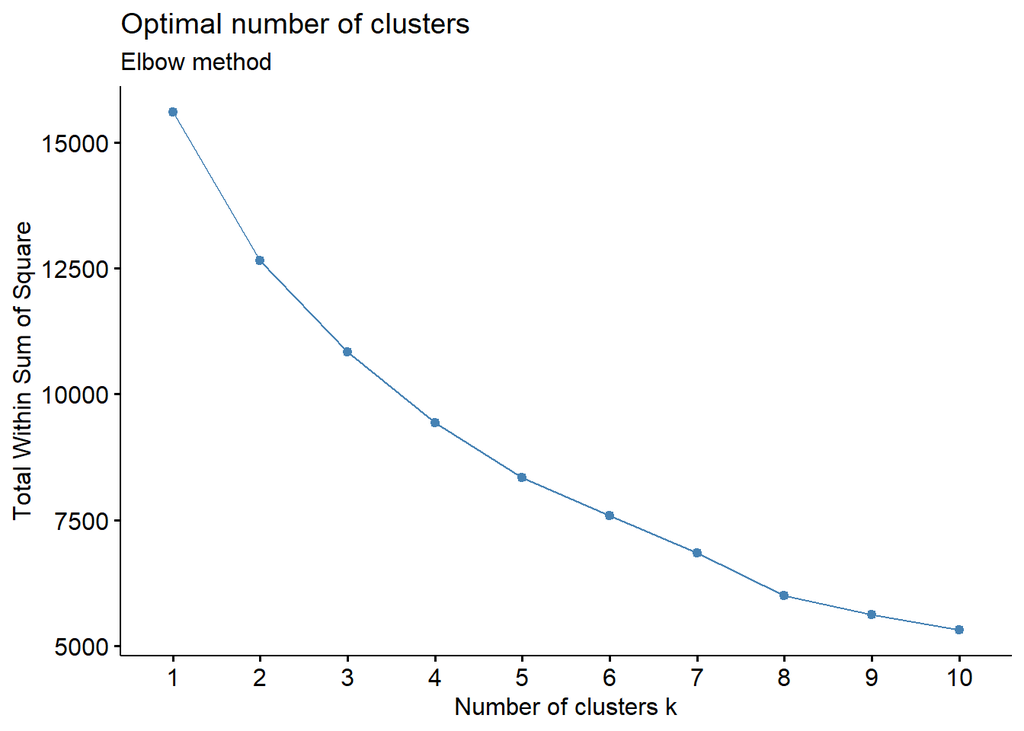

```r
fviz_nbclust(data, kmeans, method = "wss") +
  labs(subtitle = "Elbow method")
```

#### 1.2.1.2 Método de la silhueta

La silueta compara cohesión interna y separación externa. Valores altos indican que las observaciones están bien asignadas a su grupo y suficientemente alejadas de los demás.

**Mostrar código**

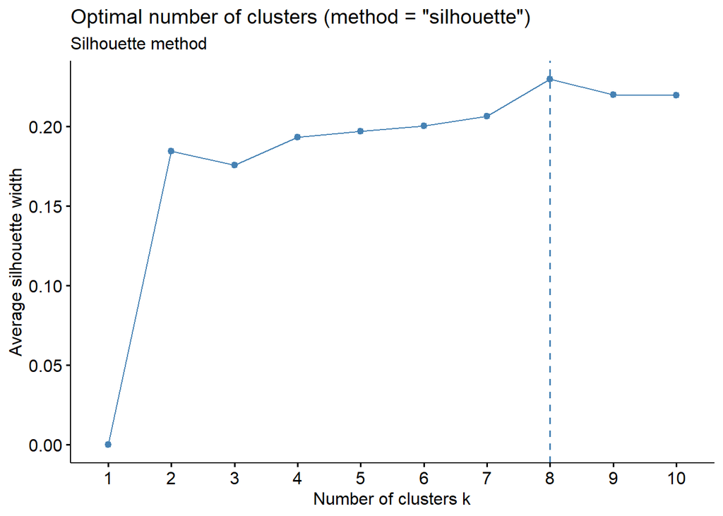

```r
fviz_nbclust(data, kmeans, method = "silhouette") +
  labs(subtitle = "Silhouette method")
```

**Mostrar código**

```
  cluster size ave.sil.width
1       1 1047          0.18
2       2  958          0.21
3       3  972          0.19
4       4  923          0.19
```

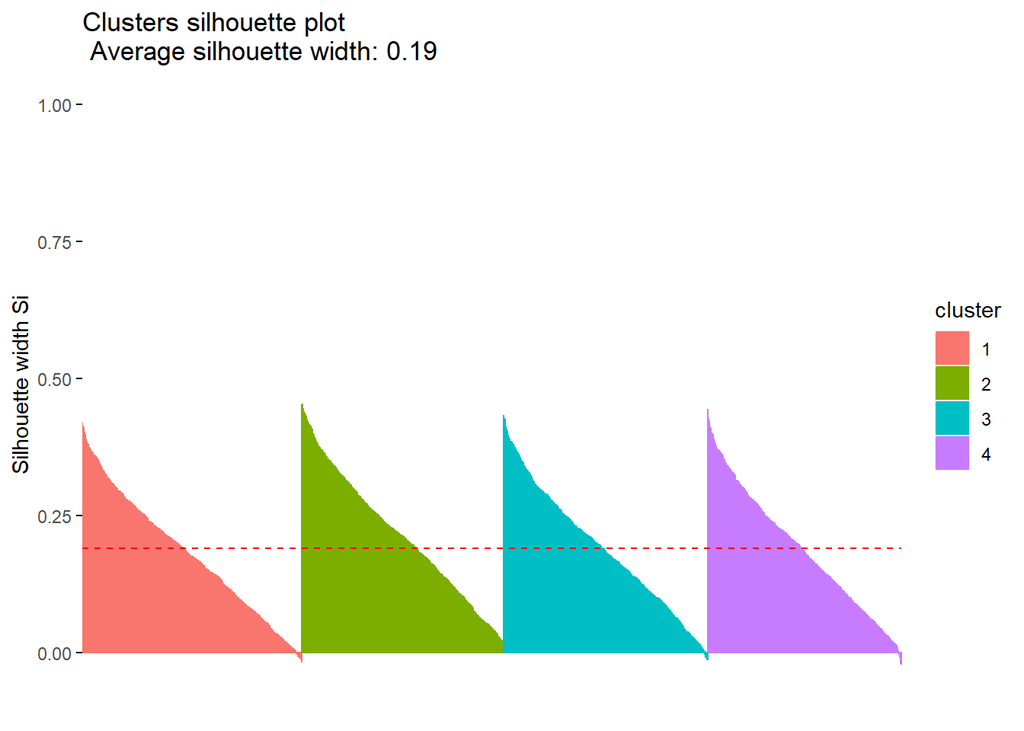

```r
sil <- silhouette(km_clusters[["cluster"]], dist(data))
fviz_silhouette(sil)
```

##### 1.2.1.2.1 Interpretación del gráfico de Silhouette

El **coeficiente de Silhouette** mide cómo de bien está asignada cada observación a su cluster en comparación con los demás clusters.

donde:

- **a(i)**: distancia media entre la observación *i* y los elementos de su mismo cluster.
- **b(i)**: distancia media entre la observación *i* y los elementos del cluster más cercano.

El valor de silhouette está acotado entre **-1 y 1**.

Interpretación práctica:

| Valor aproximado | Interpretación |
| --- | --- |
| **s ≈ 1** | La observación está muy bien asignada a su cluster |
| **s ≈ 0.5** | Buena asignación |
| **s ≈ 0** | La observación está entre dos clusters |
| **s < 0** | Probablemente está mal asignada |

En el gráfico:

- Cada barra representa una observación.
- Las barras se agrupan por cluster.
- La longitud de la barra indica la calidad de la asignación.

Un **buen clustering** presenta:

- valores de silhouette **positivos**
- clusters con **barras largas**
- pocas observaciones con valores negativos.

Además, el **promedio del índice de silhouette** suele utilizarse para comparar distintos valores de **k** y elegir el número óptimo de clusters.

#### 1.2.1.3 Método de Calinski - Harabasz

El índice de Calinski-Harabasz evalúa la relación entre dispersión entre grupos y dispersión dentro de los grupos. Cuanto mayor sea su valor, mejor separación relativa existe entre clusters.

**Mostrar código**

```r
(CH4 <- calinhara(data, km_clusters[["cluster"]]))
```

```
[1] 865.6804
```

### 1.2.2 Representación gráfica

La representación bidimensional ayuda a inspeccionar visualmente la separación entre grupos. Aunque haya pérdida de información al proyectar, suele ser una herramienta muy útil para interpretación docente.

**Mostrar código**

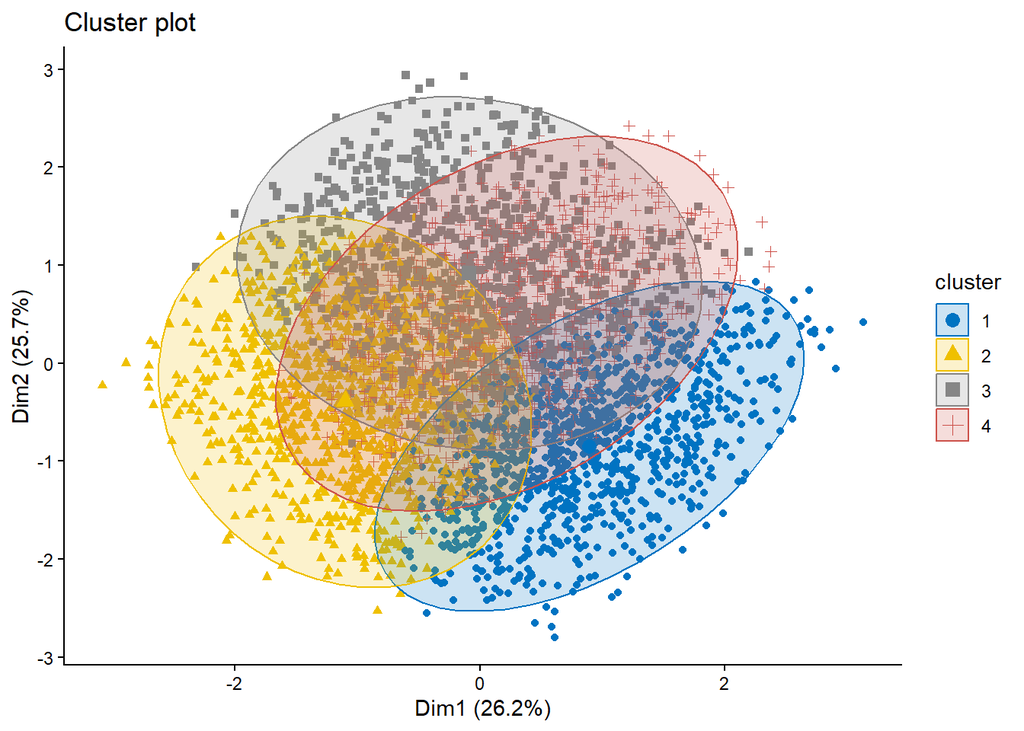

```r
fviz_cluster(
  list(data = data, cluster = km_clusters[["cluster"]]),
  ellipse.type = "norm",
  geom = "point",
  stand = FALSE,
  palette = "jco",
  ggtheme = theme_classic()
)
```

## 1.3 KMEDOIDS

PAM (Partitioning Around Medoids) es una alternativa a K-means más robusta frente a valores atípicos. En lugar de usar centroides teóricos, representa cada cluster mediante una observación real del conjunto de datos: el medoide.

**Diferencia conceptual**

Mientras que K-means resume cada grupo mediante una media, PAM lo hace mediante un individuo real. Esto lo vuelve más interpretable y menos sensible a extremos.

**Mostrar código**

```r
## Declaramos la semilla correspondiente
set.seed(123)

## Ejecutamos el proceso
(pam_clusters <- pam(x = data, k = 4, metric = "manhattan"))
```

```
Medoids:
       ID          Age Purchase.Amount..USD. Review.Rating Previous.Purchases
[1,] 2681 -0.004501801            -0.9611139    -0.6282245         -0.3012045
[2,] 3443 -1.056608079             0.7699109     0.7679891         -0.9241658
[3,] 3900  0.521551338             0.8965712    -0.9074672          0.5294106
[4,]   48  0.718821265            -0.2433719     1.0472318          0.7370644
Clustering vector:
   [1] 1 2 3 3 1 1 3 1 2 4 1 2 4 4 4 3 4 4 4 3 1 2 1 2 1 1 1 4 4 2 4 2 4 1 4 4 4
  [38] 1 1 4 4 4 2 2 4 1 3 4 3 4 1 4 1 1 3 1 4 2 4 2 1 4 1 3 4 4 2 4 1 2 1 1 1 3
  [75] 4 3 4 1 4 3 2 3 1 4 4 2 1 4 1 3 1 2 2 4 4 3 3 2 1 1 3 2 4 3 4 3 1 3 3 3 1
 [112] 2 2 1 3 3 3 4 4 4 3 2 4 3 3 4 1 2 2 2 1 1 4 3 2 2 2 4 4 3 4 4 3 1 1 2 1 3
 [149] 3 2 2 2 2 1 3 4 1 2 2 4 4 3 3 3 3 1 1 1 2 1 1 1 4 1 1 3 3 1 4 4 3 2 3 1 1
 [186] 4 3 2 1 2 3 3 1 3 3 4 3 3 4 3 1 4 1 1 2 3 2 3 1 3 1 4 2 2 4 3 1 1 1 2 4 2
 [223] 2 4 3 1 2 3 2 4 4 1 4 2 1 3 3 3 1 3 1 2 4 2 4 3 3 2 4 4 1 1 1 2 1 1 4 2 3
 [260] 1 1 2 1 2 2 1 3 4 1 1 2 4 4 4 1 2 1 1 3 2 2 1 2 1 1 2 1 1 3 4 4 1 4 1 4 1
```

[output cut: 105 more lines]

**Mostrar código**

```r
## Calculamos la distancia de Manhattan
distance2 <- dist(data, "manhattan")
```

**Mostrar código**

```r
## Calculamos el valor de contraste de Silhouette
sil <- silhouette(pam_clusters[["clustering"]], distance2)
windows() # En algunos entornos RStudio no muestra correctamente la figura
plot(sil)
```

**Mostrar código**

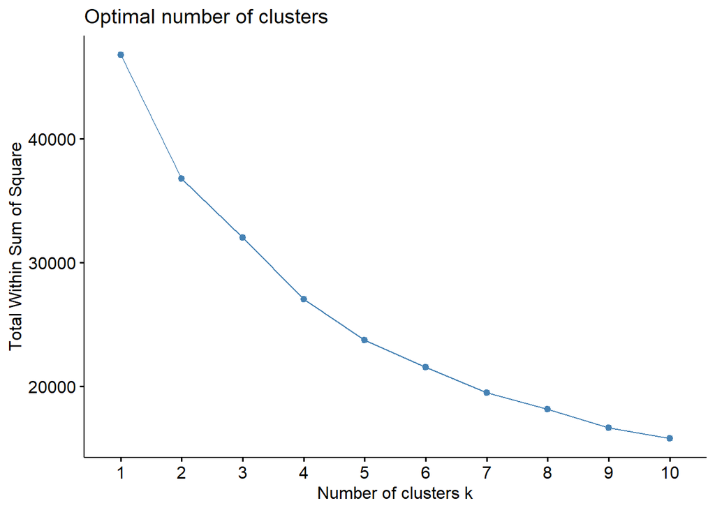

```r
## Calculamos el valor óptimo de clústers a partir de la inercia intra-cluster
fviz_nbclust(
  x = data,
  FUNcluster = pam,
  method = "wss",
  k.max = 10,
  diss = dist(data, method = "manhattan")
)
```

**Mostrar código**

[figure not shown]

```r
## Visualizamos los clusterings obtenidos a partir del método PAM
fviz_cluster(
  object = pam_clusters,
  data = data,
  ellipse.type = "t",
  repel = TRUE
) +
  theme_bw() +
  labs(title = "Resultados clustering PAM") +
  theme(legend.position = "none")
```

## 1.4 KMEANS para datos mixtos

Cuando el conjunto de datos contiene variables numéricas y categóricas, una opción útil es `kproto`, que extiende la lógica de K-means a datos mixtos combinando distancias para ambos tipos de variables.

**Atención**

Aplicar K-means clásico sobre datos mixtos sin transformación previa suele producir resultados poco fiables, porque las variables categóricas no pueden tratarse correctamente con distancia euclídea.

**Mostrar código**

```r
clusteringKMeans <- clustMixType::kproto(x = dades, type = "gower", k = 3)
```

```
# NAs in variables:
           Customer.ID                    Age                 Gender
                     0                      0                      0
        Item.Purchased               Category  Purchase.Amount..USD.
                     0                      0                      0
              Location                   Size                  Color
                     0                      0                      0
                Season          Review.Rating    Subscription.Status
                     0                      0                      0
         Shipping.Type       Discount.Applied        Promo.Code.Used
                     0                      0                      0
    Previous.Purchases         Payment.Method Frequency.of.Purchases
                     0                      0                      0
0 observation(s) with NAs.
```

**Mostrar código**

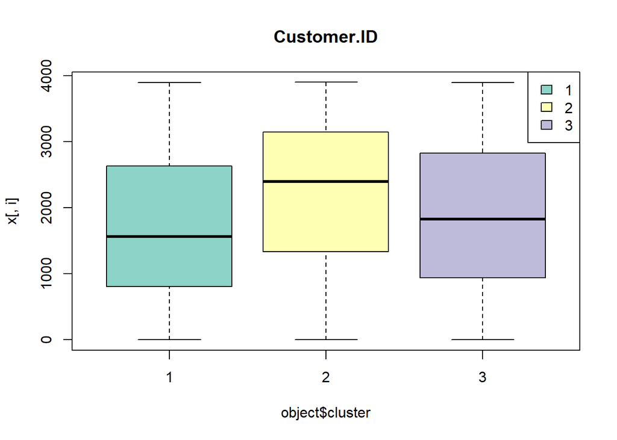

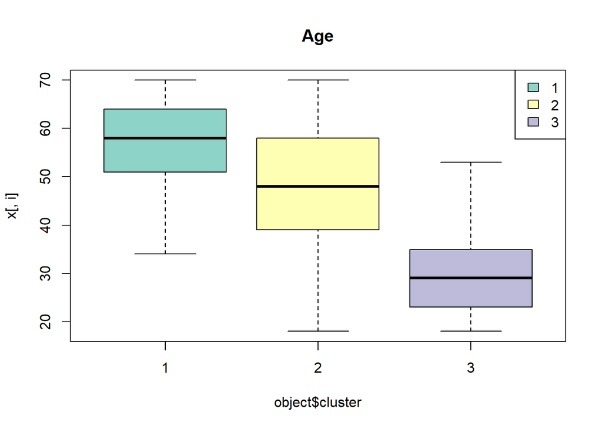

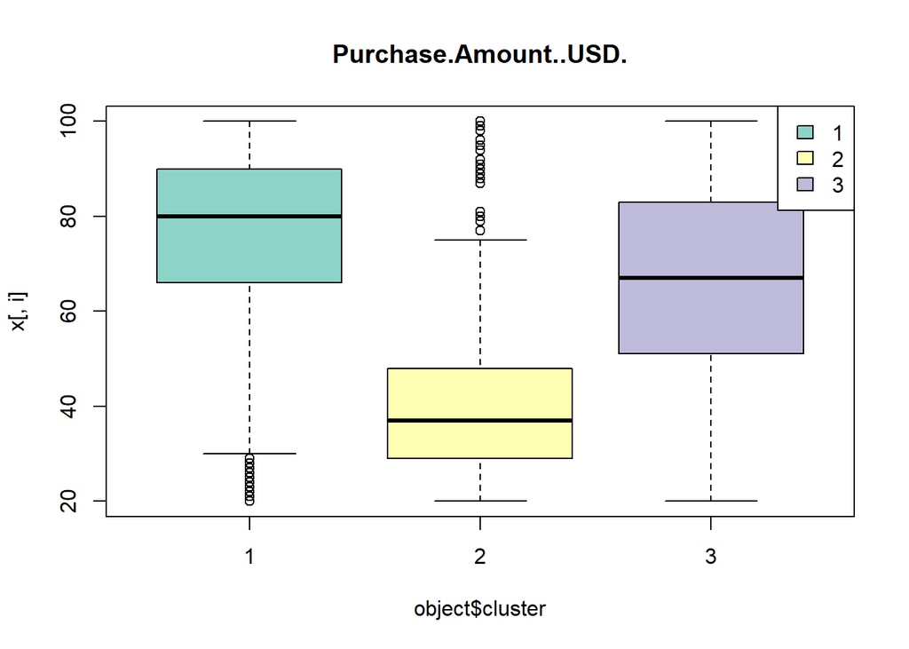

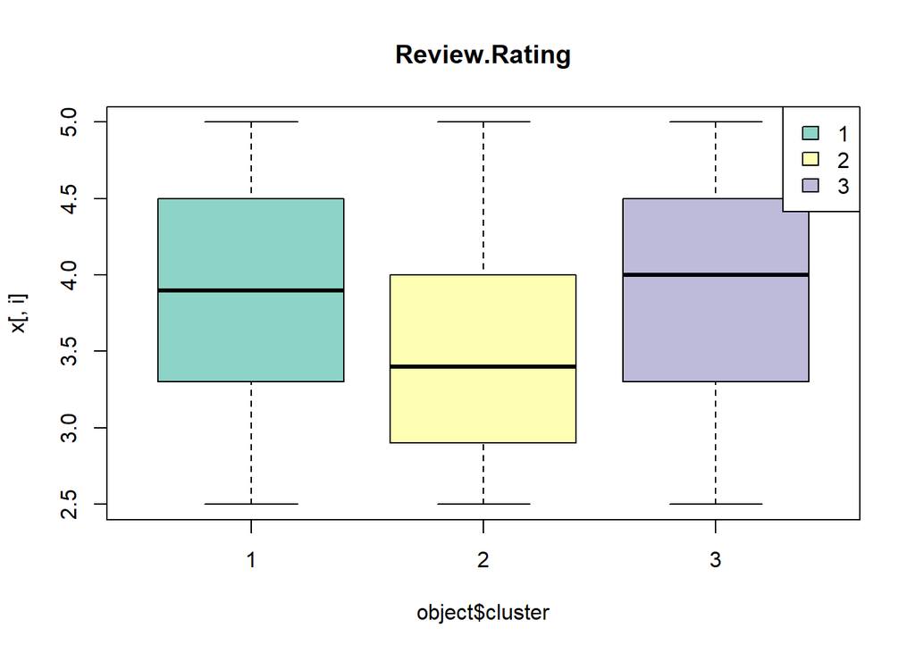

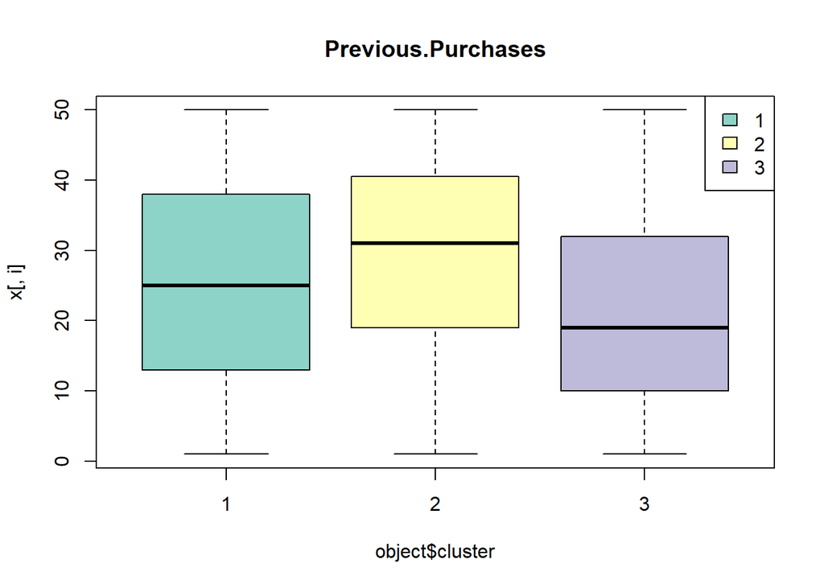

```r
plot(clusteringKMeans)
```

## 1.5 CLARA:Clustering Large Applications

En comparación con otros métodos de partición como PAM, CLARA puede gestionar conjuntos de datos mucho más grandes. Internamente, esto se logra considerando subconjuntos de tamaño fijo, de modo que los requisitos de tiempo y memoria pasan a ser aproximadamente lineales en (n), en lugar de cuadráticos.

**Mostrar código**

```r
clara(x, k, metric = c("euclidean", "manhattan", "jaccard"),
    stand = FALSE, cluster.only = FALSE, samples = 5,
    sampsize = min(n, 40 + 2 * k), trace = 0, medoids.x = TRUE,
    keep.data = medoids.x, rngR = FALSE, pamLike = FALSE, correct.d = TRUE)
```

## 1.6 fanny: Fuzzy Analysis Clustering

A diferencia de los métodos “duros”, en el clustering difuso una observación puede pertenecer parcialmente a varios grupos. Esto es útil cuando las fronteras entre clusters no están claramente delimitadas.

**Mostrar código**

```r
fanny(x, k, diss = inherits(x, "dist"), memb.exp = 2,
  metric = c("euclidean", "manhattan", "SqEuclidean"),
  stand = FALSE, iniMem.p = NULL, cluster.only = FALSE,
  keep.diss = !diss && !cluster.only && n < 100,
  keep.data = !diss && !cluster.only,
  maxit = 500, tol = 1e-15, trace.lev = 0)
```

## 1.7 Automatización de la detección del número de clusters

Cuando se quieren contrastar muchos criterios a la vez, `NbClust` resume diferentes índices y propone un número de grupos apoyándose en el consenso entre ellos.

**Mostrar código**

```r
NbClust::NbClust(data, diss = NULL, distance = "euclidean", min.nc = 2,
                 max.nc = 15, method = "kmeans")
```

# 2 Métodos Jerárquicos

Los métodos jerárquicos construyen una estructura anidada de agrupaciones. En un enfoque aglomerativo, cada observación empieza como un cluster individual y se van fusionando grupos hasta obtener un único conjunto. El resultado se resume mediante un dendrograma.

**Lectura del dendrograma**

La altura de las fusiones refleja el nivel de disimilitud entre grupos. Saltos grandes suelen sugerir cortes naturales del árbol.

## 2.1 Sólo datos numéricos

En esta primera parte se trabaja únicamente con variables numéricas para ilustrar el comportamiento de los principales criterios de enlace jerárquico.

### 2.1.1 Cálculo de distáncias

#### 2.1.1.1 Euclidean

**Mostrar código**

```r
dataNum <- dades[, varNum]
distancia <- dist(dataNum, method = "euclidean")
```

### 2.1.2 Generamos la agrupación

#### 2.1.2.1 Single

El criterio *single* une grupos a partir de la menor distancia entre elementos de ambos clusters. Suele producir el conocido efecto de encadenamiento.

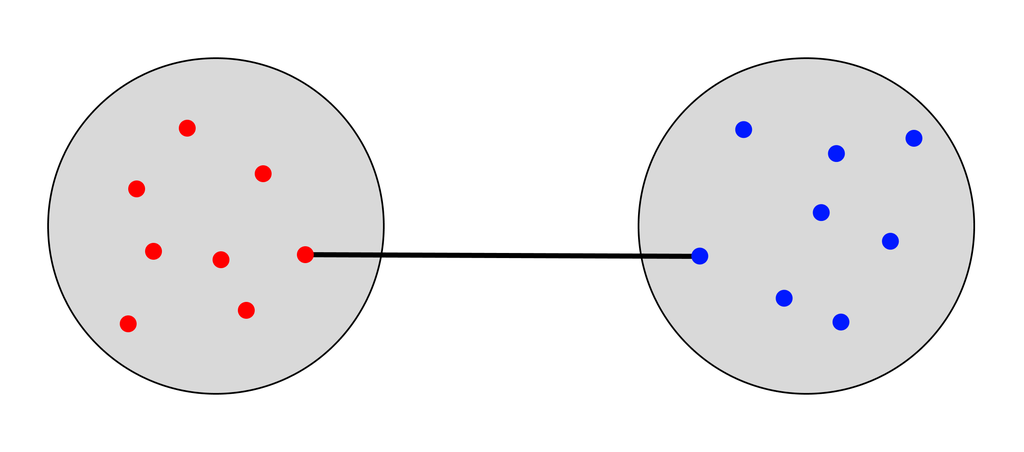

**Mostrar código**

```r
agrSingle <- hclust(distancia, method = "single")
```

#### 2.1.2.2 Complete

El criterio *complete* utiliza la mayor distancia entre elementos de dos grupos. Tiende a formar clusters más compactos.

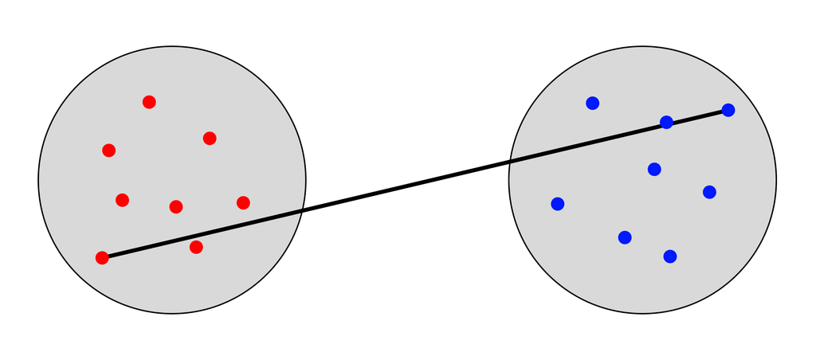

**Mostrar código**

```r
agrComplete <- hclust(distancia, method = "complete")
```

#### 2.1.2.3 Average

El enlace promedio toma la distancia media entre todos los pares de observaciones de dos clusters. Es un compromiso habitual entre *single* y *complete*.

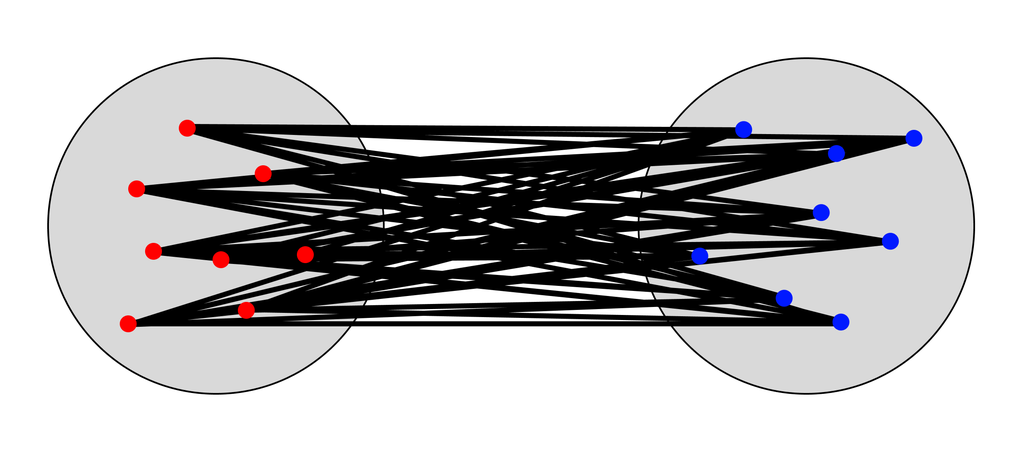

**Mostrar código**

```r
agrAverage <- hclust(distancia, method = "average")
```

#### 2.1.2.4 Mcquitty

McQuitty actualiza las distancias entre clusters promediando de forma recursiva según las fusiones previas.

**Mostrar código**

```r
agrMcquitty <- hclust(distancia, method = "mcquitty")
```

#### 2.1.2.5 Median

El criterio *median* calcula distancias a partir de centroides corregidos y puede verse afectado por inversiones en el dendrograma.

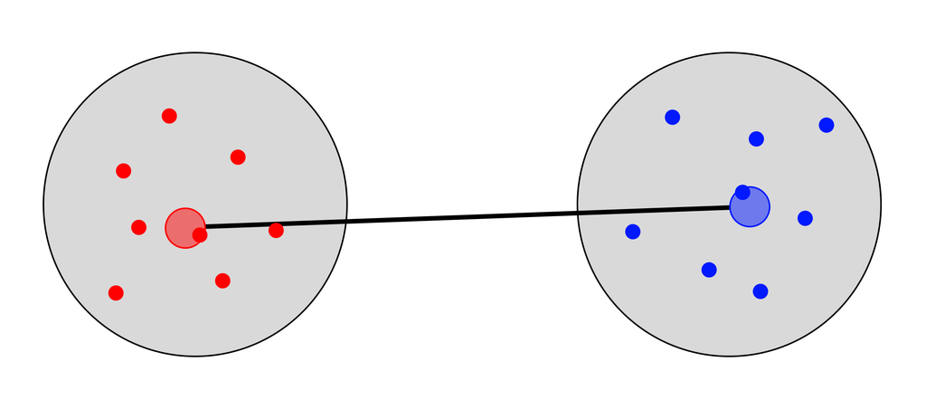

**Mostrar código**

```r
agrMedian <- hclust(distancia, method = "median")
```

#### 2.1.2.6 Centroid

En este caso la fusión depende de la distancia entre centroides de clusters. Es intuitivo, aunque no siempre conserva bien la estructura jerárquica.

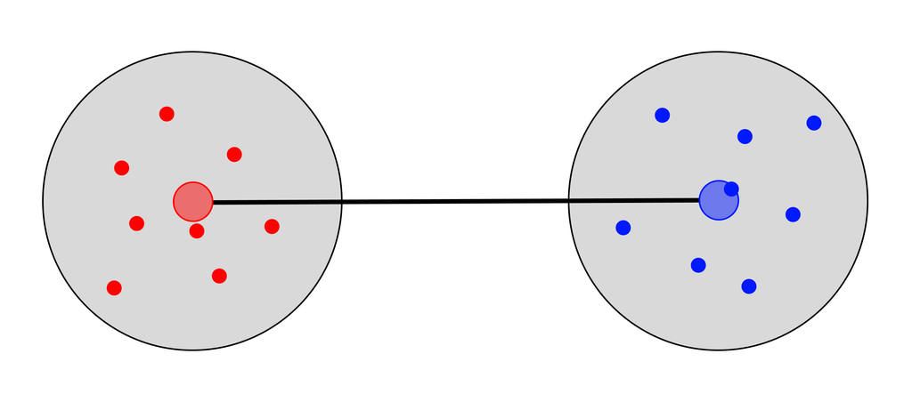

**Mostrar código**

```r
agrCentroid <- hclust(distancia, method = "centroid")
```

#### 2.1.2.7 Ward.D o Ward.D2

Ward minimiza el incremento de variabilidad interna en cada fusión. Suele producir grupos compactos y bien separados, por eso es uno de los métodos más utilizados.

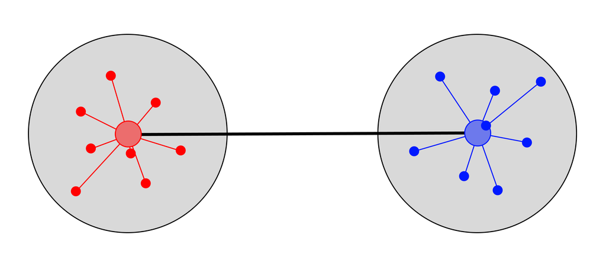

**Mostrar código**

```r
agrWard <- hclust(distancia, method = "ward.D2")
```

Realizamos la representación del dendrograma de Ward para inspeccionar visualmente posibles cortes del árbol.

**Mostrar código**

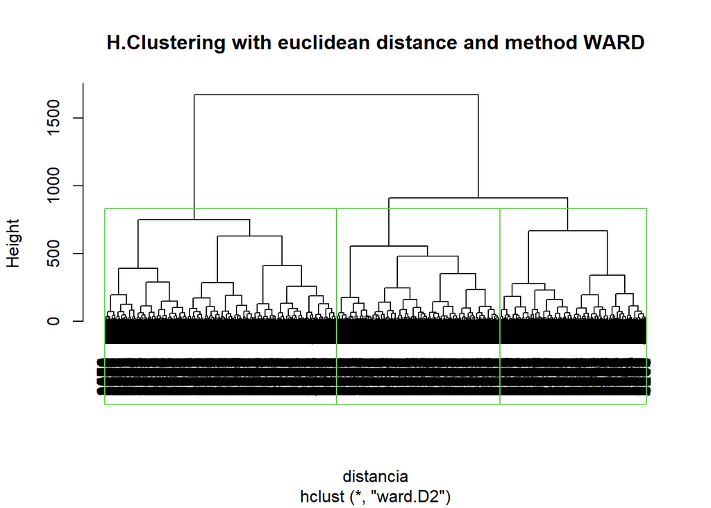

```r
plot(agrWard, main = "H.Clustering with euclidean distance and method WARD")
rect.hclust(agrWard, k = 3, border = 3)
```

Si queremos realizar la representación de todos los dendrogramas en una imagen, podemos transformar cada objeto `hclust` en un gráfico `ggplot`.

**Mostrar código**

```r
### Función para convertir hclust a ggplot
plot_dendrogram <- function(hclust_obj, method_name) {
  dendro_data <- ggdendro::dendro_data(hclust_obj)

  ggplot(ggdendro::segment(dendro_data)) +
    geom_segment(aes(x = x, y = y, xend = xend, yend = yend)) +
    theme_minimal() +
    ggtitle(method_name) +
    theme(
      axis.text = element_blank(),
      axis.ticks = element_blank(),
      axis.title = element_blank(),
      panel.grid = element_blank()
    )
}
```

**Mostrar código**

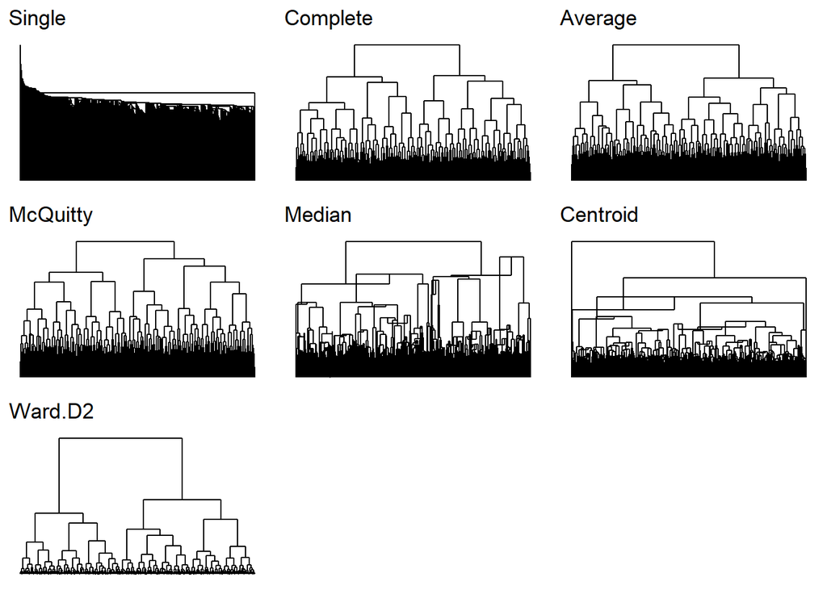

```r
### Lista de dendrogramas con nombres
dendrograms <- list(
  plot_dendrogram(agrSingle, "Single"),
  plot_dendrogram(agrComplete, "Complete"),
  plot_dendrogram(agrAverage, "Average"),
  plot_dendrogram(agrMcquitty, "McQuitty"),
  plot_dendrogram(agrMedian, "Median"),
  plot_dendrogram(agrCentroid, "Centroid"),
  plot_dendrogram(agrWard, "Ward.D2")
)

### Mostrar todos los dendrogramas en una cuadrícula
gridExtra::grid.arrange(grobs = dendrograms, ncol = 3)
```

## 2.2 Datos mixtos

Cuando coexisten variables numéricas y categóricas, la distancia euclídea deja de ser apropiada. En estos casos conviene recurrir a medidas mixtas como la distancia de Gower, que combina adecuadamente ambos tipos de información.

**Error frecuente**

Si las variables categóricas siguen siendo `character`, muchas funciones no las tratarán correctamente. Lo más seguro es convertirlas explícitamente a `factor`.

Para poder analizar datos mixtos es importante usar una distancia que permita calcular la proximidad entre individuos. Nosotros vamos a hacer uso de la distancia de `Gower`.

**Mostrar código**

```r
dissimMatrix <- daisy(dades[, c(varNum, varCat)], metric = "gower", stand = TRUE)
```

Un error muy frecuente es considerar las variables categóricas como `character`. En ese caso, deben transformarse a factor para que la función pueda tratarlas correctamente.

**Mostrar código**

```r
for (vC in varCat) {
  dades[, vC] <- as.factor(as.character(dades[, vC]))
}

dissimMatrix <- daisy(dades[, c(varNum, varCat)], metric = "gower", stand = TRUE)
```

A continuación elevamos la matriz al cuadrado para transformar la disimilitud de Gower en una forma operativa más adecuada para aplicar ciertos métodos jerárquicos, en particular Ward.

**Mostrar código**

```r
distMatrix <- dissimMatrix^2
```

A continuación, creamos los dendrogramas para cada uno de los métodos de agrupación.

**Mostrar código**

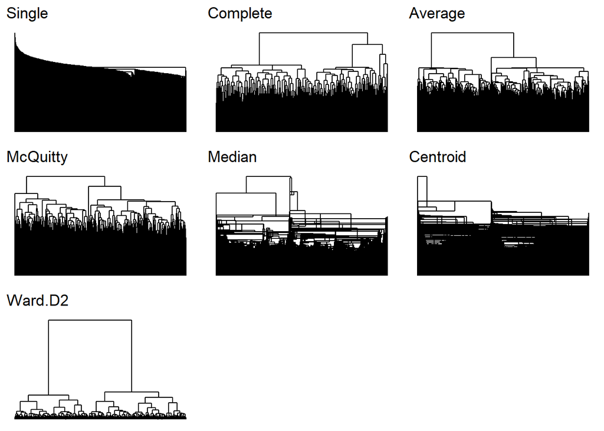

```r
## Generamos la agrupación
### single
agrSingle <- hclust(distMatrix, method = "single")
### complete
agrComplete <- hclust(distMatrix, method = "complete")
### average
agrAverage <- hclust(distMatrix, method = "average")
### mcquitty
agrMcquitty <- hclust(distMatrix, method = "mcquitty")
### median
agrMedian <- hclust(distMatrix, method = "median")
### centroid
agrCentroid <- hclust(distMatrix, method = "centroid")
### ward.D o ward.D2
agrWard <- hclust(distMatrix, method = "ward.D2")

### Lista de dendrogramas con nombres
dendrograms <- list(
  plot_dendrogram(agrSingle, "Single"),
  plot_dendrogram(agrComplete, "Complete"),
  plot_dendrogram(agrAverage, "Average"),
  plot_dendrogram(agrMcquitty, "McQuitty"),
  plot_dendrogram(agrMedian, "Median"),
  plot_dendrogram(agrCentroid, "Centroid"),
  plot_dendrogram(agrWard, "Ward.D2")
)

### Mostrar todos los dendrogramas en una cuadrícula
gridExtra::grid.arrange(grobs = dendrograms, ncol = 3)
```

### 2.2.1 Calculo de correlaciones

Una buena práctica adicional es estudiar la correlación cophenética entre la matriz de distancias original y las distancias inducidas por el dendrograma. Cuanto mayor sea esta correlación, mejor refleja el árbol la estructura de proximidades de los datos.

**Mostrar código**

```r
info <- data.frame(metricas = c("Single", "Complete", "Average", "McQuitty", "Median",
                        "Centroid", "Ward"),
           correlaciones = c(cor(distMatrix, cophenetic(agrSingle)),
                             cor(distMatrix, cophenetic(agrComplete)),
                             cor(distMatrix, cophenetic(agrAverage)),
                             cor(distMatrix, cophenetic(agrMcquitty)),
                             cor(distMatrix, cophenetic(agrMedian)),
                             cor(distMatrix, cophenetic(agrCentroid)),
                             cor(distMatrix, cophenetic(agrWard))))

(info <- info[order(info$correlaciones, decreasing = TRUE), ])
```

|  | metricas | correlaciones |
| --- | --- | --- |
| 3 | Average | 0.7333332 |
| 7 | Ward | 0.7260914 |
| 4 | McQuitty | 0.7233806 |
| 5 | Median | 0.7135397 |
| 2 | Complete | 0.7031393 |
| 6 | Centroid | 0.6971748 |
| 1 | Single | 0.1158069 |

### 2.2.2 Cortar Dendogramas

Una vez construido el dendrograma, el siguiente paso consiste en decidir dónde cortar el árbol. Ese corte determina el número final de clusters.

**Recomendación práctica**

No conviene decidir el corte únicamente “a ojo”. Lo ideal es combinar inspección visual, heurísticas y métricas de validación.

**Mostrar código**

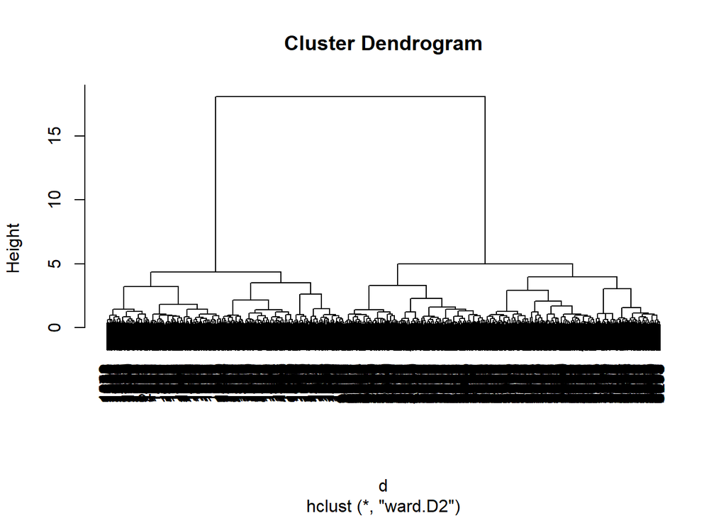

```r
d <- daisy(dades[, c(varNum, varCat)], metric = "gower", stand = TRUE)^2
h1 <- hclust(d, method = "ward.D2")
plot(h1)
```

#### 2.2.2.1 Mediante la visualización del árbol

El método más directo consiste en inspeccionar visualmente los saltos en altura y fijar un umbral razonable.

**Mostrar código**

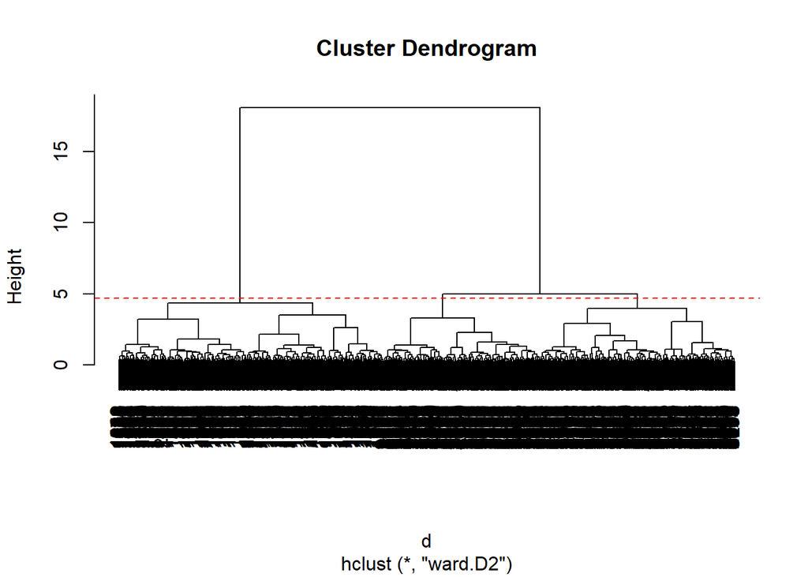

```r
d <- daisy(dades[, c(varNum, varCat)], metric = "gower", stand = TRUE)^2
h1 <- hclust(d, method = "ward.D2")
plot(h1)
abline(h = 4.7, col = "red", lty = 2)
```

#### 2.2.2.2 Heurística

También puede apoyarse la decisión con una heurística basada en los incrementos de altura de las fusiones.

**Mostrar código**

```r
head(h1[["height"]], n = 20)
```

```
 [1] 0.01727705 0.01785237 0.01866476 0.01931276 0.02005713 0.02140997
 [7] 0.02326695 0.02346719 0.02408358 0.02508672 0.02552131 0.02574270
[13] 0.02680231 0.02746482 0.02764893 0.02832588 0.02860312 0.02903139
[19] 0.02964946 0.02983467
```

**Mostrar código**

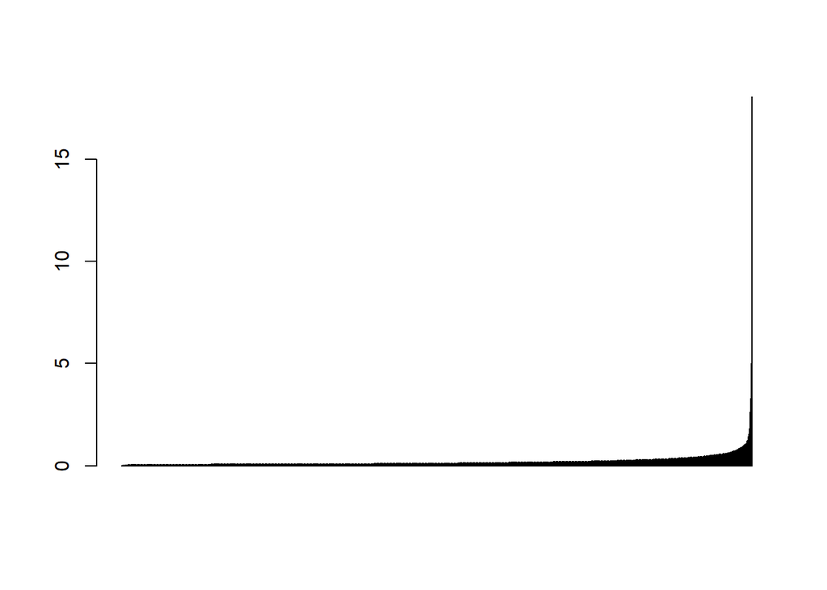

```r
barplot(h1[["height"]])
```

**Mostrar código**

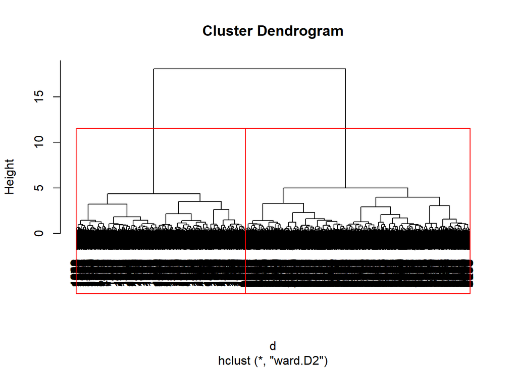

```r
plot(h1); rect.hclust(h1, h = 22.070799, border = "red")
```

**Mostrar código**

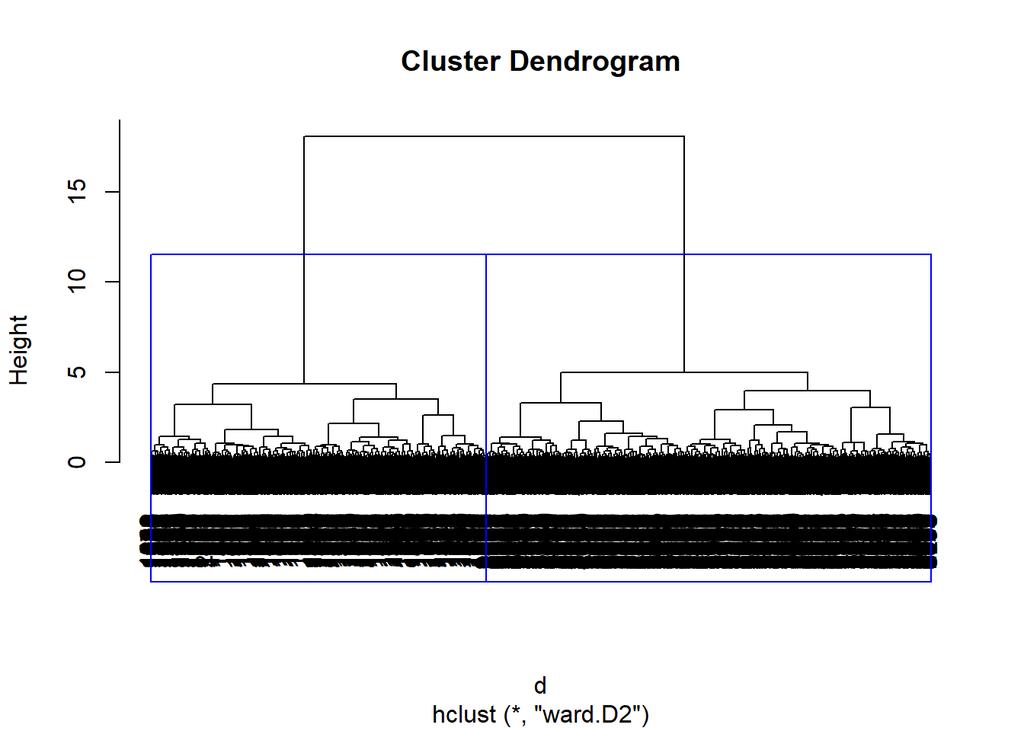

```r
plot(h1); rect.hclust(h1, h = 92.200018, border = "blue")
```

**Mostrar código**

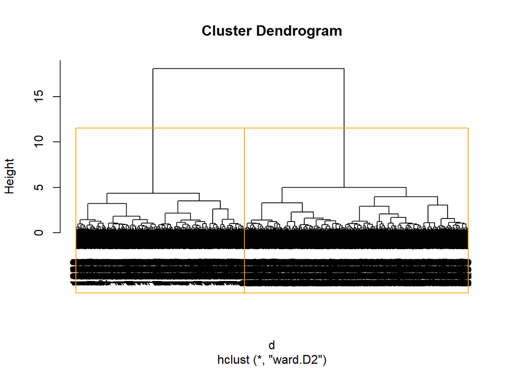

```r
plot(h1); rect.hclust(h1, h = 133.131532 ,border = "orange")
```

**Mostrar código**

```r
suggested.level <- function(hc, min = 3, max = 10){
  if(min < 2) stop("Min should be equal or higher than 2")
  intra <- rev(cumsum(hc[["height"]]))
  quot <- intra[min:(max)]/intra[(min - 1):(max - 1)]
  nb.clust <- which.min(quot) + min - 1
  return(nb.clust)
}
```

**Mostrar código**

```r
suggested.level(h1)
```

```
[1] 3
```

### 2.2.3 Etiquetado de los resultados del clustering

Una vez fijado el número de grupos, puede etiquetarse el dendrograma y extraerse la asignación final de cluster para cada observación.

**Mostrar código**

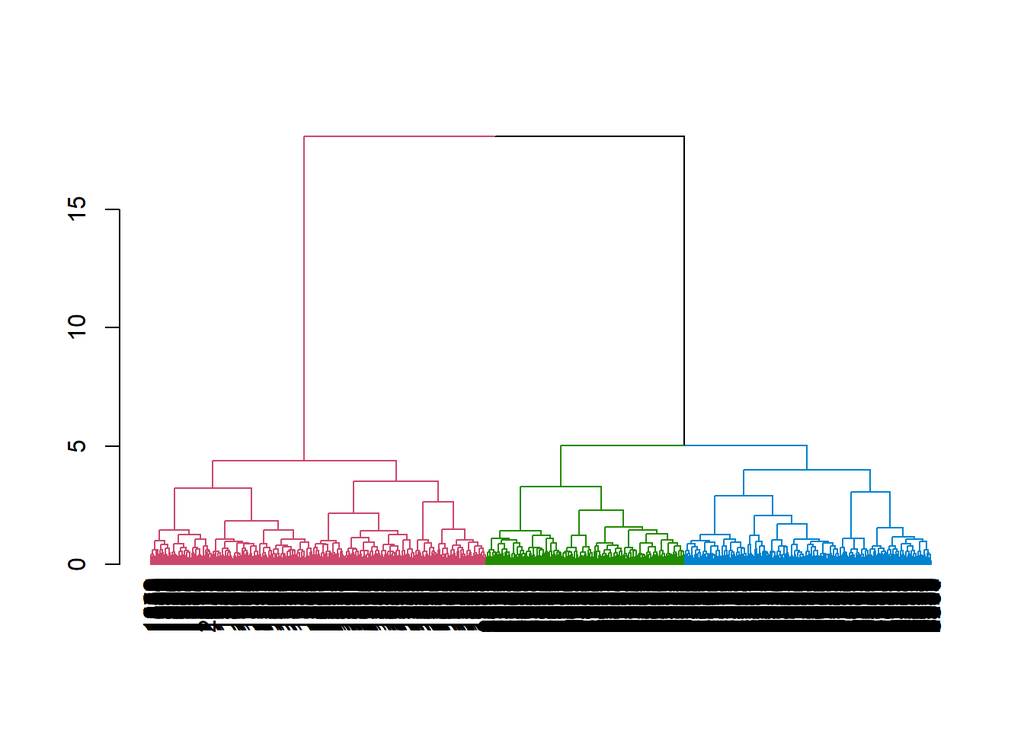

```r
as.dendrogram(h1) %>% set("branches_k_color", k = 3) %>% plot()
```

**Mostrar código**

```r
k <- 3
cut_k <- cutree(h1, k)
head(cut_k, n = 40)
```

```
 [1] 1 1 1 1 1 1 1 1 1 1 1 1 1 1 1 1 1 1 1 1 1 1 1 1 1 1 1 1 1 1 1 1 1 1 1 1 1 1
[39] 1 1
```

### 2.2.4 Validación de los cortes realizados

Finalmente, es posible validar el corte escogido con métricas internas de cohesión, separación y estructura del clustering.

**Mostrar código**

```r
fpc::cluster.stats(d, clustering = as.numeric(cut_k))
```

```
$n
[1] 3900

$cluster.number
[1] 3

$cluster.size
[1] 1675  995 1230

$min.cluster.size
[1] 995

$noisen
[1] 0

$diameter
[1] 0.7782282 0.7772257 0.6291662

$average.distance
[1] 0.3087167 0.2745693 0.3045038

$median.distance
[1] 0.3071344 0.2715715 0.3028046

$separation
[1] 0.07960016 0.04798513 0.04798513

$average.toother
[1] 0.510188 0.426618 0.447194

$separation.matrix
           [,1]       [,2]       [,3]
[1,] 0.00000000 0.08023544 0.07960016
[2,] 0.08023544 0.00000000 0.04798513
[3,] 0.07960016 0.04798513 0.00000000

$ave.between.matrix
          [,1]      [,2]     [,3]
[1,] 0.0000000 0.4997843 0.518604
[2,] 0.4997843 0.0000000 0.326981
```

[output cut: 53 more lines]

```

$cwidegap
[1] 0.1258597 0.1269368 0.1227951

$widestgap
[1] 0.1269368

$sindex
[1] 0.07710294

$corrected.rand
NULL

$vi
NULL
```

## 2.3 Other HIERARCHICAL methods

### 2.3.1 Agnes:Agglomerative Nesting

`agnes` implementa clustering jerárquico aglomerativo y proporciona información adicional sobre la calidad de la estructura jerárquica.

**Mostrar código**

```r
agnes(x, diss = inherits(x, "dist"), metric = "euclidean",
  stand = FALSE, method = "average", par.method,
  keep.diss = n < 100, keep.data = !diss, trace.lev = 0)
```

### 2.3.2 mona: MONothetic Analysis Clustering of Binary Variables

`mona` está pensado para variables binarias y construye una jerarquía divisiva basada en particiones monotéticas.

**Mostrar código**

```r
mona(x, trace.lev = 0)
```

# 3 Métricas de validación

Después de construir un clustering, conviene contrastar su calidad con varios índices. Ninguna métrica resume por sí sola toda la estructura, así que lo más recomendable es analizarlas de manera complementaria.

**Criterio general**

- Algunos índices se maximizan, como Silhouette o Calinski-Harabasz.
- Otros se minimizan, como Davies-Bouldin.
- Por eso es importante interpretar cada uno en su propia escala.

## 3.1 SSE (Sum of Squared Errors)

Esta métrica mide la varianza total dentro de cada cluster y se define como la suma de las distancias al cuadrado de cada punto al centroide de su cluster.

El objetivo de K-means es minimizar el SSE, por lo que es una métrica útil para evaluar la compactación interna de los grupos.

**Mostrar código**

```r
(sse <- clustering$tot.withinss)
```

```
[1] 1928452
```

## 3.2 Método del codo (Elbow method)

Este método representa la relación entre la suma de errores intra-cluster y el número de grupos. A medida que aumenta (k), el SSE disminuye. El “codo” aparece cuando esa mejora empieza a ser claramente marginal.

**Mostrar código**

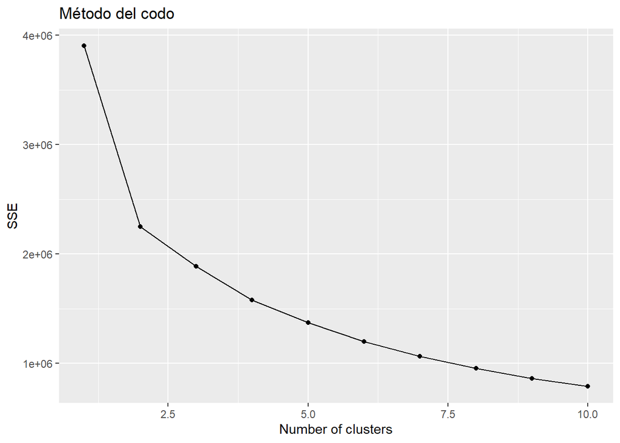

```r
sse <- c()
for (k in 1:10) {
  kmeans_model <- kmeans(dades[, varNum], k)
  sse[k] <- kmeans_model$tot.withinss
}

plot <- ggplot(data.frame(x = 1:10, y = sse), aes(x, y)) +
        geom_line() +
        geom_point() +
        labs(x = "Number of clusters", y = "SSE", title = "Método del codo")

print(plot)
```

## 3.3 Método de gap estadístico (Gap statistic method)

Este método compara el clustering observado con particiones obtenidas sobre datos de referencia aleatorios. Un mayor gap indica que la estructura detectada es más fuerte que la esperable por azar.

**Mostrar código**

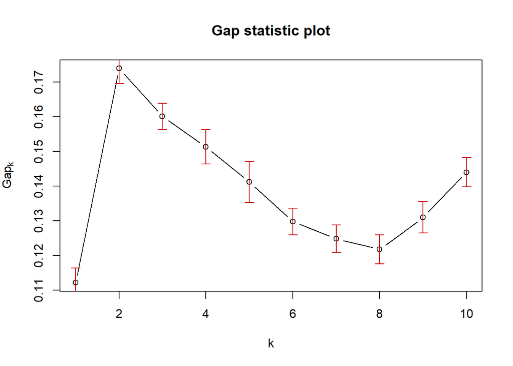

```r
gap_stat <- clusGap(dades[, varNum], FUN = kmeans, nstart = 10, K.max = 10, B = 10)
plot(gap_stat, main="Gap statistic plot")
```

## 3.4 Coeficiente de Silhouette

Mide la similitud de cada objeto con su propio grupo frente a otros grupos. Su rango va de -1 a 1: valores altos indican buena asignación, valores cercanos a 0 sugieren frontera difusa y valores negativos apuntan a mala clasificación.

**Mostrar código**

```r
sil <- cluster::silhouette(clustering$cluster, dist(dades[, varNum]))
avg_sil <- mean(sil[, 3])
summary(sil)
```

```
Silhouette of 3900 units in 3 clusters from silhouette.default(x = clustering$cluster, dist = dist(dades[, varNum])) :
 Cluster sizes and average silhouette widths:
     1049      1794      1057
0.2450539 0.3259984 0.2406909
Individual silhouette widths:
   Min. 1st Qu.  Median    Mean 3rd Qu.    Max.
-0.0556  0.1641  0.3025  0.2811  0.3986  0.5568
```

**Mostrar código**

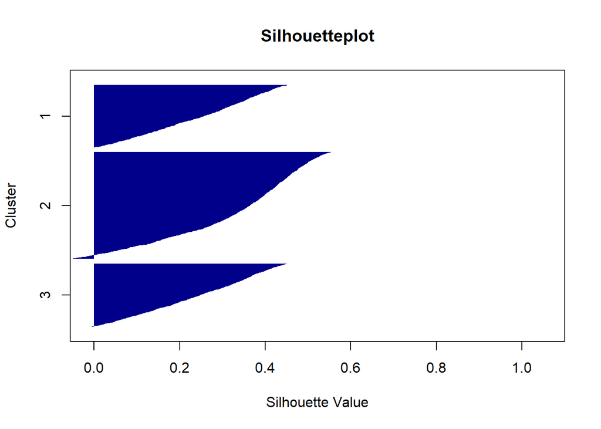

```r
Silhouetteplot(as.matrix(dades[, varNum]), Cls = sil[, "cluster"], main='Silhouetteplot')
```

**Mostrar código**

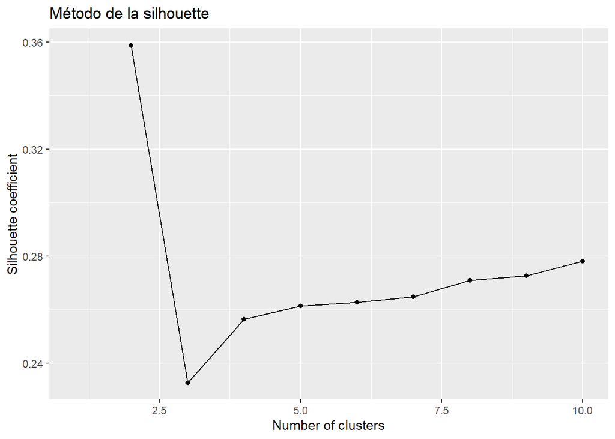

```r
sil <- c()
for (k in 2:10) {
  kmeans_model <- kmeans(dades[, varNum], k)
  sil[k] <- mean(silhouette(kmeans_model$cluster, dist(dades[, varNum]))[, 3])
}

plot <- ggplot(data.frame(x=1:10, y=sil), aes(x, y)) +
        geom_line() +
        geom_point() +
        labs(x="Number of clusters", y="Silhouette coefficient",
             title = "Método de la silhouette")

### El número óptimo de clusters es aquel que maximiza el promedio del índice de silueta
print(plot)
```